# dataviz tutorial histogram - lewis

## Dataviz histogram tutorial

author: lewis.r.liu[at]gmail.com

date: Mar 23, 2020

**task**:

Group 4: Histogram/density plot

1. Make a histogram of p values for CD4T cells
2. Change default parameters to increase clarity
3. Overlap histograms of p values for CD4T and Monocytes, and modify them to be clearer
4. Repeat step 3 but use density plot instead, and modify as needed to make it clear
5. ADVANCED: Make both an overlap of all the cell type density plots as well as a faceted version with one distribution per facet and decide which is best

**data**:

- https://github.com/megjones/2019IMED7290

**submission:**

- Make pull request to https://github.com/megjones/2019IMED7290

## Description of the data

DNA methylation data from Illumina 450k array

3 files:

- bet – beta values, matrix of probes x samples
- Meta – metadata: participant, tissue, study
- Cord_adult_ct_sub: results from whole genome LR between Study within cell types
  - CT_P = pvalue
  - CT_E = effect size
  - Some probe information

## Load data

```python
import warnings; warnings.filterwarnings('ignore')
```

```python
from pathlib import Path
import rpy2
from rpy2 import robjects
from rpy2.robjects import pandas2ri, numpy2ri
import pandas as pd
import numpy as np
```

```python
# define filepath
data2_path =  Path('..', '..', 'IMED7280_2019_datavis_example.rdata')

# Rdata is loaded to R namespace
dat2 = rpy2.robjects.r['load'](str(data2_path))
print(dat2)

# load R namespace into py namespace
cord_adult_ct_sub = robjects.r['cord_adult_ct_sub']

# convert rdataframe to pd.DataFrame
celltype_df = rpy2.robjects.pandas2ri.rpy2py(cord_adult_ct_sub)
```

```
[1] "cord_adult_ct_sub"
```

## Tutorial

```python
# dataviz libs
import holoviews as hv
import matplotlib.pyplot as plt
import seaborn as sns
```

```python
from IPython.display import display_svg
hv.extension('bokeh') # render engine
hv.notebook_extension()
```

### Task1: Make a histogram of p values for CD4T cells

```python
def plot_cd4tcell_histogram_default(data):
    fig = plt.figure()
    ax = data.plot(kind='hist')
    ax.set_title('Histogram of CD4 T-cell p-values')
    ax.xaxis.set_label_text('P-value')
    #ax.set_xscale('log')
    plt.close()
    return fig, ax
```

```
fig1
```

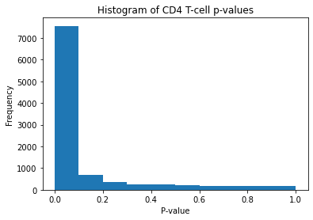

```python
fig1 = plot_cd4tcell_histogram_default(data = celltype_df.CD4T_P)[0]
print('fig1'); fig1
```

Not very informative, bin sizes are too large.

### Task2: Change default parameters to increase clarity

Adjusted bin sizes to log-scale

```python
def _make_logscale_edges(pd_series, bins = 'auto', density=False):
    """makes bins that scale by log, then return to original values"""
    freq, edges_log10 = np.histogram(pd_series.apply(lambda x: np.log10(x)), bins=bins, density = density)
    edges_original = pd.Series(edges_log10).apply(lambda x: 10**x).values
    return freq, edges_original

def _hist_skeleton(data, **kw):
    return hv.Histogram(data).options(**kw)

def histogram_logscale(data, bins = 'auto', density=False, **kw):
    freq_edge_tuple = _make_logscale_edges(data, bins, density=False)
    return _hist_skeleton(freq_edge_tuple).options(**kw)
```

```python
%output backend='bokeh'
fig2 = histogram_logscale(
                    data    = celltype_df.CD4T_P
                   , title  = 'Histogram of CD4 T-cell p-values'
                   , width  = 800
                   , logx   = True
                   , xlabel = 'pvalue'
                  ) *hv.VLine(0.05).opts(color='maroon', line_dash='dashed')
print('fig2'); fig2
```

```
fig2
```

[interactive chart not shown]

### Task 3: Overlap histograms of p values for CD4T and Monocytes

```python
def make_task3_plot():
    # slice working data
    data = celltype_df[['CD4T_P', 'Mono_P']].copy()
    data_list = [data.CD4T_P, data.Mono_P]

    # config plot params
    opt_args = dict( xlabel = 'pvalue'
                    , logx = True
                    , width = 800
                    , alpha = 0.3
                    , show_legend = True
                    , density = False
                   )
    # instantiate multiple histograms
    hist_list = [histogram_logscale(x, **opt_args) for x in data_list]
    hist_list[0] = hist_list[0].relabel(label='CD4T_P').opts(color = 'navy')
    hist_list[1] = hist_list[1].relabel(label='Mono_P').opts(color = 'orange')
    # overlay histogram plots
    fig = hist_list[0] * hist_list[1]

    # configure merged plot
    fig.opts(legend_position = 'top_left'
                      , title = 'Histogram of CD4 T-cell and Monocyte P-value distribution'
                     )
    return fig
```

Here, two histograms are overlayed after reducing the transparency (alpha values)

```python
%output backend='bokeh'
fig3 = make_task3_plot()*hv.VLine(0.05).opts(color='maroon', line_dash='dashed')
fig3.opts(legend_position='top_left')
```

[interactive chart not shown]

### Task 4: Repeat step 3 but use density plot instead

kernel density estimation.

Had to make conversion to log10P since the bin would look strange otherwise.

```python
def make_task4_plot_log10p():
    # slice working data2, then log10 transform
    data2 = celltype_df[['CD4T_P', 'Mono_P']].copy()
    data2 = data2.apply(lambda x: -np.log10(x))
    data2 = data2.rename(columns = dict(CD4T_P = 'CD4T', Mono_P = 'Monocytes'))

    # assign datapoints
    p1, p2 = data2.CD4T, data2.Monocytes

    # kde plot
    fig = hv.Distribution(p1, label = p1.name) * hv.Distribution(p2, label = p2.name)
    fig = fig* hv.VLine(-np.log10(0.05)).opts(color='black', line_dash = 'dashed')
    fig.opts(legend_position = 'top_right'
              , width = 800
              , xlabel = '-log10 pvalues'
              , title = 'KDE plot of CD4 T-cell and Monocyte -Log10 P-value distribution'
             )
    return fig
```

```python
%output backend='bokeh'
fig4a = make_task4_plot_log10p()
fig4a.opts(width=800)
```

[interactive chart not shown]

### Task 5: Make both an overlap of all the cell type density plots as well as a faceted version with one distribution per facet and decide which is best

Prepare data

```python
# subset dataset to keep only celltypes p-val columns
celltype_pval_colnames = [x for x in celltype_df.columns if x.endswith("_P")]
# apply -log10 transform
new_data = celltype_df[celltype_pval_colnames].apply(lambda x: -np.log10(x))
```

```python
def make_distribution_holomap(data):
    """holomaps are orderdicts of plotdata"""
    Distributions = {}
    for col in data.columns:
        subset = data[col]
        output = hv.Distribution(subset, label = subset.name)
        Distributions[col] = output
    return hv.HoloMap(Distributions)

def add_vline():
    """add vertical line at -log10(0.05)"""
    return hv.VLine(-np.log10(0.05)).opts(color='black', line_dash = 'dashed')
```

```python
def make_fig5_hmap(data):
    """adds vline to holomap, suppresses custom title repetition"""
    holomap = make_distribution_holomap(data)
    holomap.opts(title= "{label}", xlabel='-log(Pvalue)')
    return holomap*add_vline()
```

```python
# fig5 facetgrid
hv.NdLayout(make_fig5_hmap(new_data)).\
    opts(title='Facetgrid of density plots for all celltypes').\
    cols(3)
```

[interactive chart not shown]

```python
# Fig5, overlay
make_fig5_hmap(new_data).overlay().\
    opts(title='Overlay of density plots for all celltypes'
         , width = 800
         , height = 350
        )
```

[interactive chart not shown]